# GARCH Model with R

Cong Wang https://congwang.org/

2022-08-04

# 1 Model Introduction

**GARCH model** (Generalized Autoregressive Conditional Heteroskedasticity model) describes the variance of the current error term follows an **ARMA** model (Autoregressive Moving Average) instead of constant.

$$y_t = x_t + \epsilon_t$$
$y_t$ is a stock return, $x_t$ is a mean reverting process, and $\epsilon_t$ is the error term. $\epsilon_t=\sqrt{\delta^2}z_t$, where $z_t \sim D(0,1)$ and $D$ is a specified distribution. $\delta_t$ is time-varying and follow an ARMA process as follow:
$$\delta_t = \omega +
\alpha_1 \epsilon^2_{t-1} + ... + \alpha_q \epsilon^2_{t-q} + \beta_1
\delta^2_{t-1} +...+ \beta_p \delta^2_{t-p}$$

## Use rugarch Package to Fit a GARCH Model

The easy way to fit a GARCH model is using **rugarch** package through those two simple steps:

1. Setting the model specification.
2. Fit the model and get the parameters.

# 2 Data Exploration

## 2.1 Import Data

In this example I gonna use the Google stock data. It is downloaded through the **quantmod** package.

```r
library(quantmod)
googl <- getSymbols("GOOGL", from="2010-01-01", to="2022-08-03", auto.assign = F)
head(googl[, 1:5], 5)
```

```
##            GOOGL.Open GOOGL.High GOOGL.Low GOOGL.Close GOOGL.Volume
## 2010-01-04   15.68944   15.75350  15.62162    15.68443     78169752
## 2010-01-05   15.69520   15.71171  15.55405    15.61537    120067812
## 2010-01-06   15.66216   15.66216  15.17417    15.22172    158988852
## 2010-01-07   15.25025   15.26526  14.83108    14.86737    256315428
## 2010-01-08   14.81481   15.09635  14.74249    15.06557    188783028
```

Calculate daily return.

```r
daily_ret <- (googl$GOOGL.Close-stats::lag(googl$GOOGL.Close))/stats::lag(googl$GOOGL.Close)
```

Convet the data into data frame, and change the row and column names.

```r
daily_ret <- data.frame(index(daily_ret), daily_ret)
colnames(daily_ret) <- c("date", "return")
rownames(daily_ret) <- 1:nrow(daily_ret)
```

## 2.2 Plot the Return

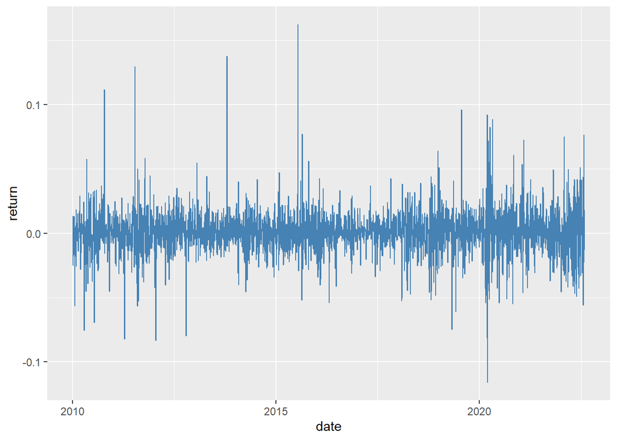

```r
library(ggplot2)
p1 <- ggplot(daily_ret, aes(x=date, y=return))
p1 + geom_line(colour="steelblue")
```

As it shows in the plot, the return of stock is not stationary. Approximately the mean is 0, but the volatility seems to be random. In the following, I will plot the histogram of the return and compare it with normal distribution.

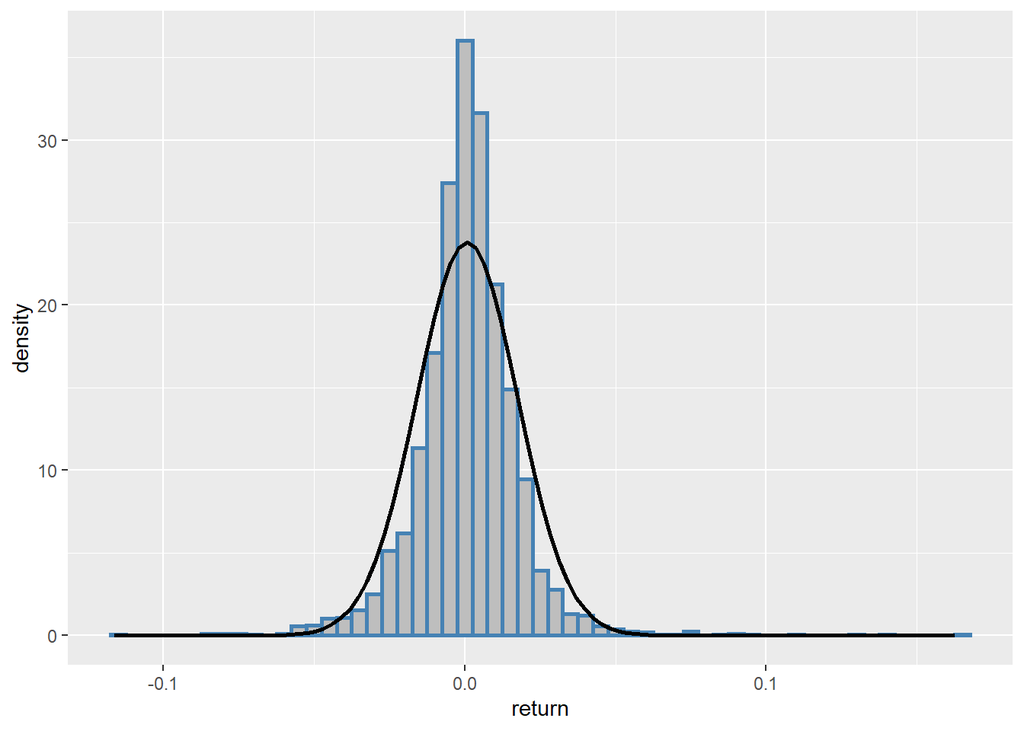

```r
p2 <- ggplot(daily_ret)

p2 + geom_histogram(aes(x=return, y=..density..), binwidth = 0.005, color="steelblue", fill="grey", size=1) +
  stat_function(fun = dnorm, args = list(mean = mean(daily_ret$return, na.rm = T), sd = sd(daily_ret$return, na.rm = T)), size=1)
```

**1. Skewness**

As we can see from the plot the return is not symmetrically distributed, rather it is positive skewed (or right skewed). A positive skewness indicating on average it gives us a positive return. But the level of skewness is not very high. *p.s. If the distribution is highly right skewed we can use a log transformation to convert it into normal in avioding any misleading results.*

**2. Kurtosis**

The plot show us positive Kurtosis comparing with normal distribution. Kurtosis can be used as a measure of risk. A large Kurtosis is associated with a high level of risk because it indicates that there are high probabilities of extremely large and small returns (**Heavy-tailed**). Meanwhile, a small kurtosis shows a moderate level of risk for the probabilities of extreme returns are relatively low.

## 2.3 Calculate the Monthly Volatility

Convert back the data frame to xts, then use `rollapply` to calculate rolling volatility. For monthly rolling volatility I choose 20 trading days for one moth.

```r
library(PerformanceAnalytics)
library(xts)
daily_ret_xts <- xts(daily_ret[,-1], order.by=daily_ret[,1])
realizedvol <- rollapply(daily_ret_xts, width = 20, FUN=sd.annualized)
```

Convert back the xts data to dataframe.

```r
vol <- data.frame(index(realizedvol), realizedvol)
colnames(vol) <- c("date", "volatility")
```

Plot the monthly volatility.

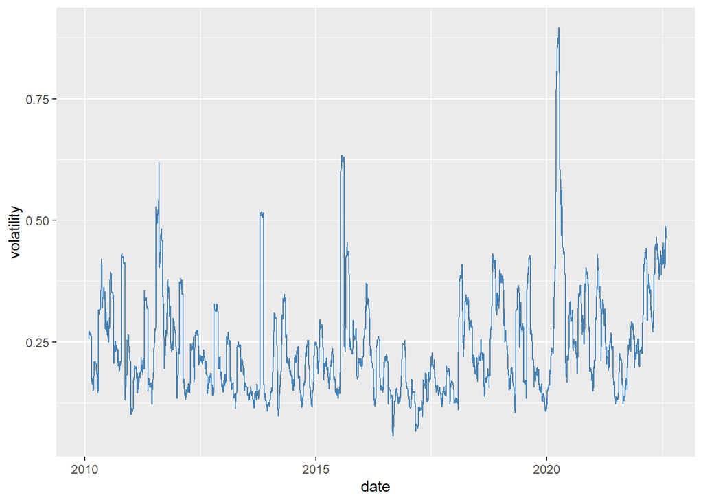

```r
p3 <- ggplot(vol, aes(x=date, y=volatility))
p3 +
  geom_line( color="steelblue")
```

We can see that most of the time the volatility is around 0.25, while there are 4 times the volatility become very high.

# 3 Fit a GARCH Model

## 3.1 1. Model Specification

Setting the model specification using the `ugarchspec` function.

```r
library(rugarch)
garch_spec <- ugarchspec(variance.model=list(model="sGARCH", garchOrder=c(1,1)), mean.model=list(armaOrder=c(0,0)))
```

For the standard GARCH model, I specify a constant to mean ARMA model, which means that arma0rder = c(0,0). We consider the GARCH(1,1) model and the distribution of the conditional error term is the normal distribution.

## 3.2 2. Fit the Model

```r
fit_garch <- ugarchfit(spec = garch_spec, data = vol[-c(1:19),2])
fit_garch
```

```
##
## *---------------------------------*
## *          GARCH Model Fit        *
## *---------------------------------*
##
## Conditional Variance Dynamics
## -----------------------------------
## GARCH Model  : sGARCH(1,1)
## Mean Model   : ARFIMA(0,0,0)
## Distribution : norm
##
## Optimal Parameters
## ------------------------------------
##         Estimate  Std. Error   t value Pr(>|t|)
## mu      0.183618    0.001297 141.60640  0.00000
## omega   0.000276    0.000027  10.22687  0.00000
## alpha1  0.999000    0.033681  29.66070  0.00000
## beta1   0.000000    0.007195   0.00001  0.99999
##
## Robust Standard Errors:
##         Estimate  Std. Error   t value Pr(>|t|)
## mu      0.183618    0.010063 18.247557 0.000000
## omega   0.000276    0.000121  2.285651 0.022275
## alpha1  0.999000    0.084218 11.862082 0.000000
## beta1   0.000000    0.005298  0.000014 0.999989
##
## LogLikelihood : 4348.208
##
## Information Criteria
## ------------------------------------
##
## Akaike       -2.7600
## Bayes        -2.7523
## Shibata      -2.7600
## Hannan-Quinn -2.7572
##
## Weighted Ljung-Box Test on Standardized Residuals
## ------------------------------------
##                         statistic p-value
## Lag[1]                       1862       0
```

[output cut: 37 more lines]

```
## Negative Sign Bias  0.3633 0.7164
## Positive Sign Bias  1.0105 0.3123
## Joint Effect        2.3665 0.4999
##
##
## Adjusted Pearson Goodness-of-Fit Test:
## ------------------------------------
##   group statistic p-value(g-1)
## 1    20      7769            0
## 2    30      7843            0
## 3    40      9979            0
## 4    50      8988            0
##
##
## Elapsed time : 0.2733741
```